# Прогнозирование заказов такси

Имеются исторические данные о заказах такси в аэропортах. Чтобы привлекать больше водителей в период пиковой нагрузки, нужно спрогнозировать количество заказов такси на следующий час.

Данные лежат в файле `taxi.csv`. Количество заказов такси за 10-ти минутный интервал находится в столбце `num_orders`.

Наша задача построить модель для такого предсказания, что бы значение метрики *RMSE* на тестовой выборке было не больше 48.

## Подготовка

### Библиотеки

```python
import pandas as pd
import numpy as np
import random
import lightgbm as lgb
import seaborn as sns
import matplotlib.pyplot as plt
import time

from sklearn.metrics import r2_score
from numpy. linalg import inv, det
from sklearn.model_selection import train_test_split

from sklearn.preprocessing import OrdinalEncoder
from sklearn.datasets import make_regression
from lightgbm import LGBMRegressor
from sklearn.preprocessing import StandardScaler

from sklearn.tree import DecisionTreeRegressor
from sklearn.ensemble import RandomForestRegressor
from sklearn.linear_model import LinearRegression
from sklearn.metrics import mean_squared_error

from sklearn.model_selection import TimeSeriesSplit

from sklearn.metrics import mean_squared_error
from sklearn.metrics import make_scorer

import warnings
warnings.filterwarnings('ignore')

from sklearn.model_selection import GridSearchCV
from sklearn.model_selection import RandomizedSearchCV
from scipy.stats import randint
from datetime import datetime
import lightgbm as lgb
from sklearn.model_selection import RepeatedStratifiedKFold
from sklearn.model_selection import cross_val_score
from sklearn.dummy import DummyRegressor

from statsmodels.tsa.seasonal import seasonal_decompose


pd.options.mode.chained_assignment = None
```

### Загрузка

```python
# Загружаем данные, назначая дату индексом
df = pd.read_csv('taxi.csv', index_col=[0], parse_dates=[0])#
df.info()
```

```
<class 'pandas.core.frame.DataFrame'>
DatetimeIndex: 26496 entries, 2018-03-01 00:00:00 to 2018-08-31 23:50:00
Data columns (total 1 columns):
 #   Column      Non-Null Count  Dtype
---  ------      --------------  -----
 0   num_orders  26496 non-null  int64
dtypes: int64(1)
memory usage: 414.0 KB
```

```python
df.head() # Выводим для ознакомления 5 первых строк
```

| datetime | num_orders |
| --- | --- |
| 2018-03-01 00:00:00 | 9 |
| 2018-03-01 00:10:00 | 14 |
| 2018-03-01 00:20:00 | 28 |
| 2018-03-01 00:30:00 | 20 |
| 2018-03-01 00:40:00 | 32 |

```python
df.tail() # Выводим для ознакомления 5 последних строк
```

| datetime | num_orders |
| --- | --- |
| 2018-08-31 23:10:00 | 32 |
| 2018-08-31 23:20:00 | 24 |
| 2018-08-31 23:30:00 | 27 |
| 2018-08-31 23:40:00 | 39 |
| 2018-08-31 23:50:00 | 53 |

### Пропуски

```python
# Знакомимся с пропусками в данных
pd.DataFrame(round(df.isna().mean()*100,)).style.background_gradient('coolwarm')
```

|  | 0 |
| --- | --- |
| num_orders | 0.000000 |

### Сортировка

```python
# Отсортируем данные по индексу
df.sort_index(inplace=True)
```

### Монотонность

```python
# Проверим индексы на монотонность
df.index.is_monotonic_increasing
```

```
True
```

### Ресемплирование

```python
# Выполняем ресемплирование данных по одному часу.
df = df.resample('1H').sum()
df
```

| datetime | num_orders |
| --- | --- |
| 2018-03-01 00:00:00 | 124 |
| 2018-03-01 01:00:00 | 85 |
| 2018-03-01 02:00:00 | 71 |
| 2018-03-01 03:00:00 | 66 |
| 2018-03-01 04:00:00 | 43 |
| ... | ... |
| 2018-08-31 19:00:00 | 136 |
| 2018-08-31 20:00:00 | 154 |
| 2018-08-31 21:00:00 | 159 |
| 2018-08-31 22:00:00 | 223 |
| 2018-08-31 23:00:00 | 205 |

4416 rows × 1 columns

### Изменение типа данных

```python
df['num_orders'] = df['num_orders'].astype('uint16') # Изменяем тип данных int64 -> uint8
df.info()
```

```
<class 'pandas.core.frame.DataFrame'>
DatetimeIndex: 4416 entries, 2018-03-01 00:00:00 to 2018-08-31 23:00:00
Freq: H
Data columns (total 1 columns):
 #   Column      Non-Null Count  Dtype
---  ------      --------------  -----
 0   num_orders  4416 non-null   uint16
dtypes: uint16(1)
memory usage: 43.1 KB
```

## Анализ

**План на раздел**

### Распределение заказов

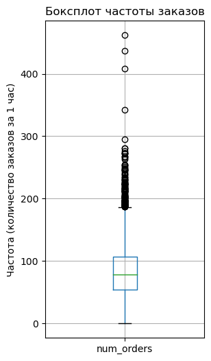

|  | num_orders |
| --- | --- |
| count | 4416.000000 |
| mean | 84.422781 |
| std | 45.023853 |
| min | 0.000000 |
| 25% | 54.000000 |
| 50% | 78.000000 |
| 75% | 107.000000 |
| max | 462.000000 |

```python
# Боксплот частоты заказов
box_plot=df.boxplot(grid= True, figsize=(3, 6));# Распределение значений
box_plot.set(xlabel='',ylabel='Частота (количество заказов за 1 час)',
             title='Боксплот частоты заказов');
plt.show()
df.describe()
```

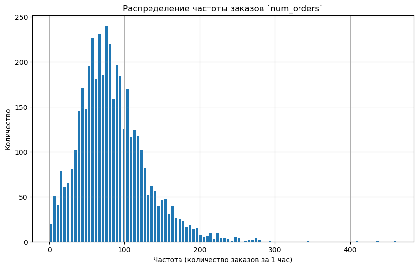

```python
# Гистограмма распределения частоты заказов
df.hist(bins=100, rwidth= .7, range = (0, 462), figsize=(10, 6))
plt.xlabel('Частота (количество заказов за 1 час)')
plt.ylabel('Количество')
plt.title("Распределение частоты заказов `num_orders`");
plt.show()
```

### Скользящее среднее за весь периуд (пол года)

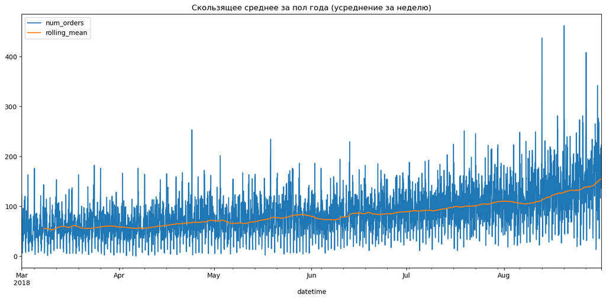

```python
df_rm = df.copy()
df_rm['rolling_mean'] = df_rm.rolling(24*7).mean()# Скользящее среднее

plt.figure(figsize=(16, 24))
plt.subplot(311)
df_rm.plot(ax=plt.gca())
plt.title('Скользящее среднее за пол года (усреднение за неделю)')
plt.show()
```

[figure not shown]

```python
df_rm = df.copy()
df_rm['2018-03-01' : '2018-04-01']['rolling_mean'] = df_rm['2018-03-01' : '2018-04-01'].rolling(12).mean()# Скользящее среднее

plt.figure(figsize=(16, 24))
plt.subplot(311)
df_rm['2018-03-01' : '2018-04-01'].plot(ax=plt.gca())
plt.title('Скользящее среднее за март месяц (усреднение за 12 часов)');
plt.show()
```

[figure not shown]

```python
df_rm = df.copy()
df_rm['2018-03-01' : '2018-03-07'][
    'rolling_mean'] = df_rm['2018-03-01' : '2018-03-07'].rolling(6).mean()# Скользящее среднее

plt.figure(figsize=(16, 24))
plt.subplot(311)
df_rm['2018-03-01' : '2018-03-08'].plot(ax=plt.gca())
plt.title('Скользящее среднее за неделю (усреднение за 6 часов)');
plt.show()
```

### Тренд, сезонность и шум за весь периуд

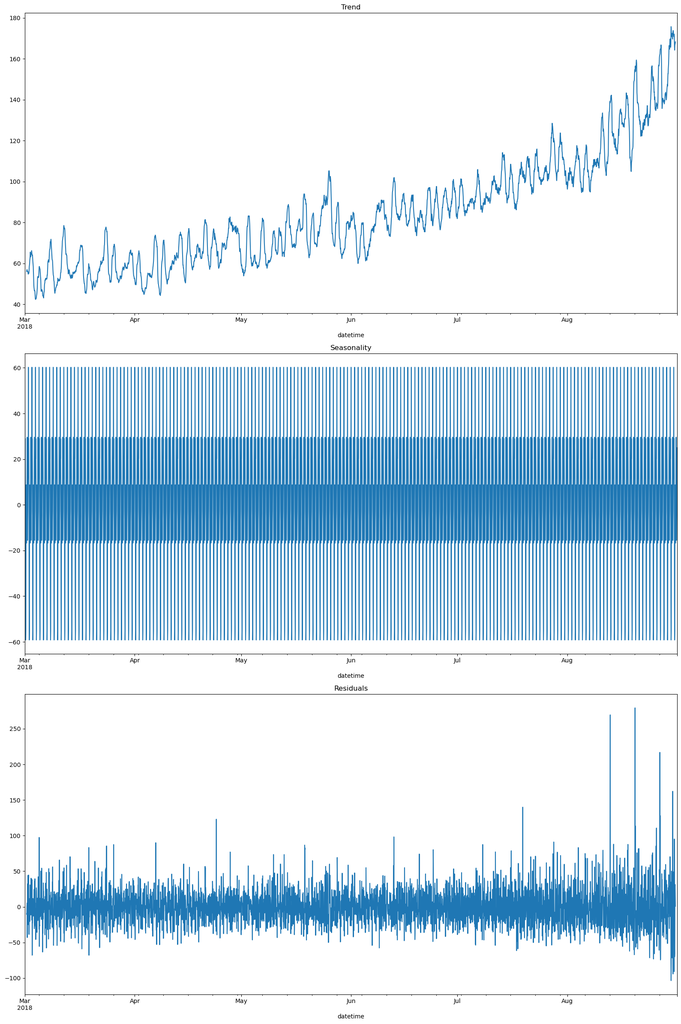

```python
decomposed = seasonal_decompose(df)# Тренды и сезонность

plt.figure(figsize=(16, 24))
plt.subplot(311)
decomposed.trend.plot(ax=plt.gca())
plt.title('Trend')
plt.subplot(312)
decomposed.seasonal.plot(ax=plt.gca())
plt.title('Seasonality')
plt.subplot(313)
decomposed.resid.plot(ax=plt.gca())
plt.title('Residuals')
plt.tight_layout()
plt.show()
```

### Сезонность за один месяц

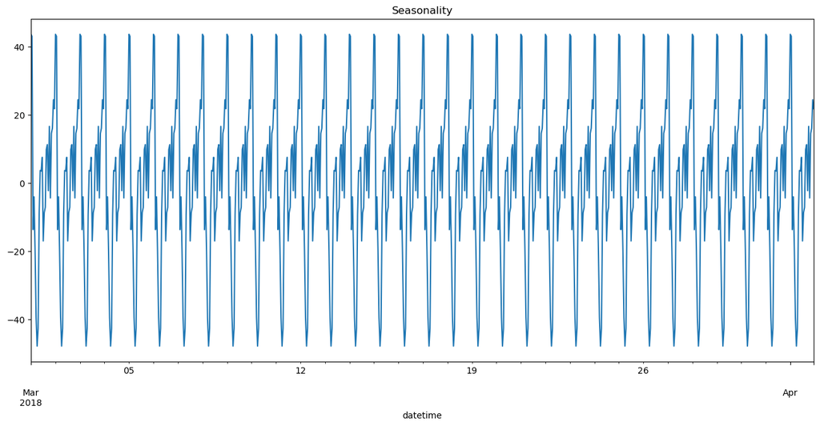

```python
decomposed = seasonal_decompose(df['2018-03-01' : '2018-04-01'])# Сезонность за один месяц
plt.figure(figsize=(16, 24))
plt.subplot(312)
decomposed.seasonal.plot(ax=plt.gca())
plt.title('Seasonality')
plt.show()
```

**Вывод**

Можно отметить суточные колебания с амлитудой 50 и тренд на увеличение с 55 до 155 за пол года.

## Подготовка признаков

### Выбор обучающих признаков

При работе с временными рядами выбор признаков является самым ответственным этапом. Необходимо подобрать признаки, которые действительно зависят от времени и влияют на цель, что бы модель была максимально точной.

Выберем следующие признаки:

- номера наблюдения,
- квадрат номера наблюдения, для учёта нелинейности тренда;
- номер дня в месяце, для учёта внутримесячных сезонностей;
- номер дня в неделе, для учёта внутринедельных сезонностей;
- номер часа в сутках, для учёта внутридневных сезонностей;
- лаги в диапазоне от 1 и 24 часов, для учёта внутридневной сезонности;
- лаг в 7 * 24 часа, для учёта недельной сезонности;
- скользящие средние с окном 12 часов.

### Функция для создания обучающих признаков

```python
# Определим функцию для создания обучающих признаков:
# производных от даты,
# а так же Отстающие значения
# и Скользящее среднее.

def make_features(df_copy, max_lag, rolling_mean_size):
    df_copy['number'] = df_copy.reset_index().index
    df_copy['number_2'] = df_copy.reset_index().index ** 2#
    df_copy['day'] = df_copy.index.day
    df_copy['dayofweek'] = df_copy.index.dayofweek
    df_copy['hour'] = df_copy.index.hour

    for lag in range(1, max_lag + 1):
        df_copy['lag_{}'.format(lag)] = df_copy['num_orders'].shift(lag)
    df_copy['lag_7*24'] = df_copy['num_orders'].shift(7*24)

    for r in [ 1]: #, 6
        df_copy['rolling_mean_{}'.format(rolling_mean_size*r)] = df_copy[
            'num_orders'].shift().rolling(rolling_mean_size*r).mean()

    return df_copy
```

### Cгенерируем обучающие признаки

```python
df_copy = df.copy()# Cоздадим копию исходного датафрейма

# Cгенерируем обучающие признаки.
make_features(df_copy, 24, 12)

# Удалим строки с пропусками, возникшими в результате введения в df_copy
# Отстающих значений и Скользящего среднего.
df_copy = df_copy.dropna()

df_copy
```

| datetime | num_orders | number | number_2 | day | dayofweek | hour | lag_1 | lag_2 | lag_3 | lag_4 | ... | lag_17 | lag_18 | lag_19 | lag_20 | lag_21 | lag_22 | lag_23 | lag_24 | lag_7*24 | rolling_mean_12 |
| --- | --- | --- | --- | --- | --- | --- | --- | --- | --- | --- | --- | --- | --- | --- | --- | --- | --- | --- | --- | --- | --- |
| 2018-03-08 00:00:00 | 143 | 168 | 28224 | 8 | 3 | 0 | 94.0 | 127.0 | 108.0 | 76.0 | ... | 17.0 | 19.0 | 10.0 | 73.0 | 66.0 | 24.0 | 121.0 | 100.0 | 124.0 | 69.250000 |
| 2018-03-08 01:00:00 | 78 | 169 | 28561 | 8 | 3 | 1 | 143.0 | 94.0 | 127.0 | 108.0 | ... | 38.0 | 17.0 | 19.0 | 10.0 | 73.0 | 66.0 | 24.0 | 121.0 | 85.0 | 78.333333 |
| 2018-03-08 02:00:00 | 65 | 170 | 28900 | 8 | 3 | 2 | 78.0 | 143.0 | 94.0 | 127.0 | ... | 50.0 | 38.0 | 17.0 | 19.0 | 10.0 | 73.0 | 66.0 | 24.0 | 71.0 | 80.250000 |
| 2018-03-08 03:00:00 | 68 | 171 | 29241 | 8 | 3 | 3 | 65.0 | 78.0 | 143.0 | 94.0 | ... | 34.0 | 50.0 | 38.0 | 17.0 | 19.0 | 10.0 | 73.0 | 66.0 | 66.0 | 82.083333 |
| 2018-03-08 04:00:00 | 60 | 172 | 29584 | 8 | 3 | 4 | 68.0 | 65.0 | 78.0 | 143.0 | ... | 58.0 | 34.0 | 50.0 | 38.0 | 17.0 | 19.0 | 10.0 | 73.0 | 43.0 | 83.500000 |
| ... | ... | ... | ... | ... | ... | ... | ... | ... | ... | ... | ... | ... | ... | ... | ... | ... | ... | ... | ... | ... | ... |
| 2018-08-31 19:00:00 | 136 | 4411 | 19456921 | 31 | 4 | 19 | 207.0 | 217.0 | 197.0 | 116.0 | ... | 230.0 | 194.0 | 276.0 | 246.0 | 158.0 | 198.0 | 142.0 | 72.0 | 113.0 | 163.416667 |
| 2018-08-31 20:00:00 | 154 | 4412 | 19465744 | 31 | 4 | 20 | 136.0 | 207.0 | 217.0 | 197.0 | ... | 99.0 | 230.0 | 194.0 | 276.0 | 246.0 | 158.0 | 198.0 | 142.0 | 179.0 | 170.916667 |
| 2018-08-31 21:00:00 | 159 | 4413 | 19474569 | 31 | 4 | 21 | 154.0 | 136.0 | 207.0 | 217.0 | ... | 268.0 | 99.0 | 230.0 | 194.0 | 276.0 | 246.0 | 158.0 | 198.0 | 166.0 | 168.583333 |
| 2018-08-31 22:00:00 | 223 | 4414 | 19483396 | 31 | 4 | 22 | 159.0 | 154.0 | 136.0 | 207.0 | ... | 78.0 | 268.0 | 99.0 | 230.0 | 194.0 | 276.0 | 246.0 | 158.0 | 242.0 | 164.916667 |
| 2018-08-31 23:00:00 | 205 | 4415 | 19492225 | 31 | 4 | 23 | 223.0 | 159.0 | 154.0 | 136.0 | ... | 35.0 | 78.0 | 268.0 | 99.0 | 230.0 | 194.0 | 276.0 | 246.0 | 173.0 | 167.583333 |

4248 rows × 32 columns

### Матрица корреляции всех признаков в виде тепловой карты heatmap

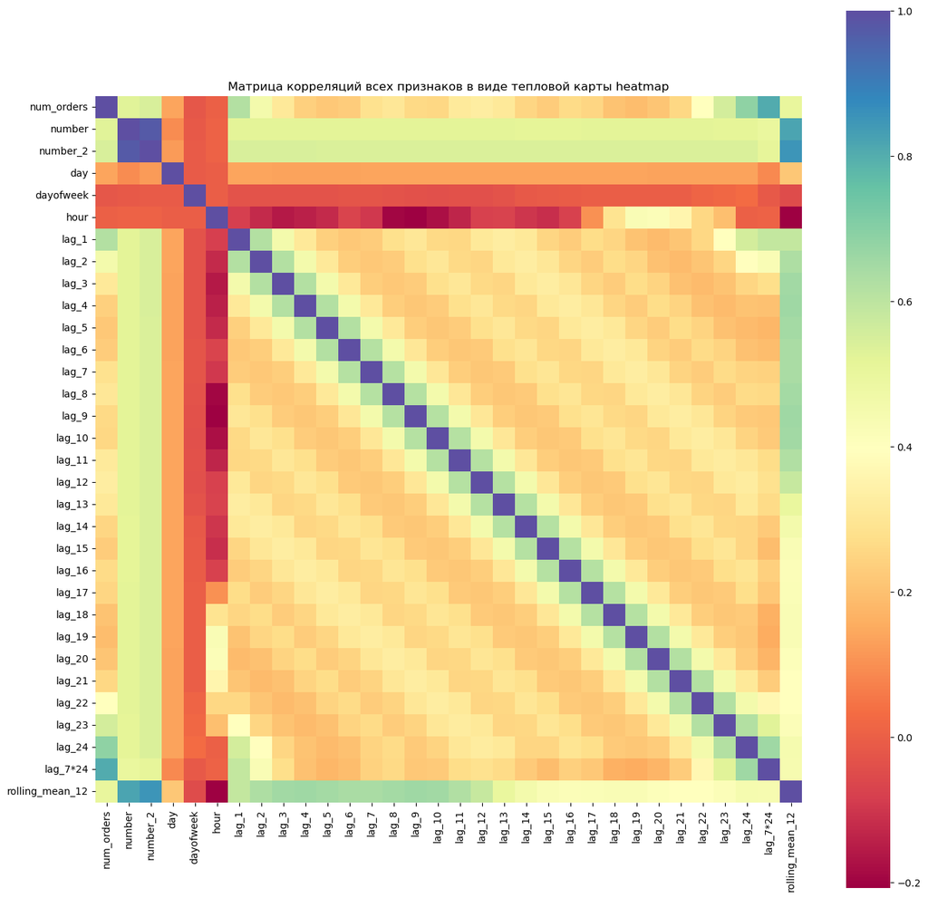

```python
# Построим матрицу корреляций всех признаков в виде тепловой карты heatmap.
plt.figure(figsize = (16,16))
sns.heatmap(df_copy.corr(), annot = False, square=True, cmap= 'Spectral', fmt = '.1g')#, cbar=False
plt.title('Матрица корреляций всех признаков в виде тепловой карты heatmap');
plt.show()
```

```python
# Для корректной работы преобразуем техникой OHE цикличные признаки.
# А так же удалим один элемент, чтобы не угодить в дамми-ловушку фиктивных признаков.
df_copy = pd.get_dummies(df_copy, columns=['hour', 'day', 'dayofweek'], drop_first=True) # , 'month'
```

### Разбиение на выборки

```python
# Разделим данные на обучающую и тестовую выборки.
train, test = train_test_split(df_copy, shuffle=False, test_size=0.1)# shuffle=False - не перетасовывать данные

# Выделим целевой признак из обучающей, валидационной и тестовой выборки.
target_train = train['num_orders']
target_test = test['num_orders']
features_train = train.drop('num_orders', axis=1)
features_test = test.drop('num_orders', axis=1)
```

## Подбор модели

#### Функция разделения данных

Так как для временных рядов не подходит разбивка на случайные подвыборки, обычно применяемая для перекрёстного поиска. Используем специальную функцию, которая формирует подвыборки кросс-валидации, не нарушая порядок расположения наблюдений (не перемешивая рандомно данные). Модель не сможет заглянуть в будущее. Создадим такой объект.

```python
tscv = TimeSeriesSplit(n_splits=9)

print(tscv)
```

```
TimeSeriesSplit(gap=0, max_train_size=None, n_splits=9, test_size=None)
```

#### Функция потерь для алгоритма подбора гиперпараметров

```python
def rmse(y_pred, y):
    return -np.sqrt(mean_squared_error(y_pred, y))

my_scorer = make_scorer(rmse)
```

#### Функция поиска по сетке

```python
def grid_search(name, model, parameters, X, y):
    model_grid = GridSearchCV(model, param_grid=parameters, scoring=my_scorer,
            n_jobs=-1, cv=tscv, verbose=-1)
    # n_jobs=-1 использовать все ЦП для обучения, по умолчанию 1, использовать 1 ЦП
    #start_time = datetime.now().timestamp()
    model_grid = model_grid.fit(X, y);
    #time_spent_lr = datetime.now().timestamp() - start_time
    res = round(-model_grid.best_score_, 3)
    # Лучший результат и гиперпараметры
    print('Модель -',name, '.  Лучшие показатели при поиске по сетке')
    print('Гиперпараметры: '+str(model_grid.best_params_))
    print('Результат: ', res)

    return name, res
```

### LinearRegression

```python
%%time

# Линейная регрессия
def Mean_score_mini(model, features, target):
    scores = []
    sample_size = int(len(target)/9)# зададим размер блока, если их всего девять
    valid_indexes, train_indexes = [], []

    for i in range(0, int(len(target)), sample_size):
        valid_indexes = target.index[i:i+sample_size]# < массив из индексов для валидационного блока >
        train_indexes = [x for x in target.index if x not in valid_indexes]# < массив из индексов
        # для обучающей выборки >
        features_train, target_train = features.loc[train_indexes, :], target.loc[train_indexes]
        features_valid, target_valid = features.loc[valid_indexes, :], target.loc[valid_indexes]

        mean_model = model.fit(features_train, target_train)
        predicted_valid = mean_model.predict(features_valid)
        score = rmse(target_valid, predicted_valid)# Оценим качество модели
        scores.append(score)


    return  np.mean(scores), mean_model

# Посчитаем среднее качество модели по итогам  кросс-валидации
lin_reg = LinearRegression() # инициализируем модель LinearRegression
mean_score, lin_reg = Mean_score_mini(lin_reg, features_train, target_train)# Запустим модель посредством
# функции кросс-валидации
model_lr = 'LinearRegression', -round(mean_score, 3)


print("Линейная регрессия\nРезультат:", model_lr[1])
```

```
Линейная регрессия
Результат: 24.645
CPU times: user 3.08 s, sys: 87 ms, total: 3.17 s
Wall time: 430 ms
```

### DecisionTreeRegressor

```python
%%time

# Дерево
# Запуск поиска по сетке

name = 'DecisionTreeRegressor()'
gm = DecisionTreeRegressor()
g_space={'max_depth': np.arange(5, 9, step=1), # максимальный уровень (глубину) каждого дерева
              'max_features':np.arange(13, 16, step=1), # Максимальное количество признаков,
         # которое модели разрешается опробовать при каждом разбиении.
         # По умолчанию в Scikit-Learn это значение устанавливается равным квадратному корню
         # из общего числа переменных в наборе данных.
              'min_samples_leaf':np.arange(6, 8, step=1), # Минимальное количество образцов,
         # необходимое для нахождения в листовом узле каждого дерева. В Scikit-Learn значение по умолчанию равно 1.
              'min_samples_split':np.arange(2, 3, step=1) # Минимальное количество образцов,
         # необходимое для разбиения внутреннего узла каждого дерева. В Scikit-Learn значение по умолчанию равно 2.
          }

# Лучший результат модели 'RandomForestRegressor()'
model_dt = grid_search(name, gm, g_space, features_train, target_train)
print(model_dt)
```

```
Модель - DecisionTreeRegressor() .  Лучшие показатели при поиске по сетке
Гиперпараметры: {'max_depth': 6, 'max_features': 15, 'min_samples_leaf': 7, 'min_samples_split': 2}
Результат:  26.645
('DecisionTreeRegressor()', 26.645)
CPU times: user 1.54 s, sys: 412 ms, total: 1.95 s
Wall time: 1.69 s
```

```python
params_dt = {'max_depth': 7, 'max_features': 15, 'min_samples_leaf': 6, 'min_samples_split': 2}
```

### RandomForestRegressor

```python
%%time

# Лес
# Запуск поиска по сетке

name = 'RandomForestRegressor()'
gm = RandomForestRegressor()
g_space={'max_depth': np.arange(8, 10, step=1), # максимальный уровень (глубину) каждого дерева в модели случайного леса
              'n_estimators':np.arange(7, 10, step=1), # Количество деревьев решений в лесу
              'max_features':np.arange(4, 6, step=1), # Максимальное количество признаков, которое модели случайного леса
         #разрешается опробовать при каждом разбиении. По умолчанию в Scikit-Learn это значение
         #устанавливается равным квадратному корню из общего числа переменных в наборе данных.
              'min_samples_leaf':np.arange(1, 3, step=1), # Минимальное количество образцов, необходимое для нахождения
         #  в листовом узле каждого дерева. В Scikit-Learn значение по умолчанию равно 1.
              'min_samples_split':np.arange(2, 3, step=1) #np.arange(1, 2, step=1) Минимальное количество образцов, необходимое
         #для разбиения внутреннего узла каждого дерева. В Scikit-Learn значение по умолчанию равно 2.
          }

model_rf = grid_search(name, gm, g_space, features_train, target_train) # Лучший результат модели
print(model_rf)
```

```
Модель - RandomForestRegressor() .  Лучшие показатели при поиске по сетке
Гиперпараметры: {'max_depth': 9, 'max_features': 5, 'min_samples_leaf': 2, 'min_samples_split': 2, 'n_estimators': 8}
Результат:  26.072
('RandomForestRegressor()', 26.072)
CPU times: user 408 ms, sys: 44.2 ms, total: 452 ms
Wall time: 567 ms
```

```python
params_rf = {'max_depth': 9, 'max_features': 5, 'min_samples_leaf': 2, 'min_samples_split': 2, 'n_estimators': 8}
```

### LGBMRegressor

```python
%%time


# LGBMRegressor
# Запуск поиска по сетке
name = 'lgb.LGBMRegressor()'
gm = lgb.LGBMRegressor()
g_space={'num_leaves': np.arange(14, 15, step=1),
          'n_estimators': np.arange(14, 15, step=1),#'num_iterations'
          'max_depth': np.arange(6, 7, step=1),
          'lambda_l2':np.arange(1, 2, step=1),
          'learning_rate':[0.1],
          'bagging_fraction':[0.1],
          #'subsample':[1],
          #'reg_lambda':[0],
          'verbose' : [-1]
        };

model_lgb = grid_search(name, gm, g_space, features_train, target_train); # Поиск гиперпараметров по сетке
# с помощью модели GridSearchCV
print(model_lgb);
```

```
Модель - lgb.LGBMRegressor() .  Лучшие показатели при поиске по сетке
Гиперпараметры: {'bagging_fraction': 0.1, 'lambda_l2': 1, 'learning_rate': 0.1, 'max_depth': 6, 'n_estimators': 14, 'num_leaves': 14, 'verbose': -1}
Результат:  24.913
('lgb.LGBMRegressor()', 24.913)
CPU times: user 227 ms, sys: 11.4 ms, total: 238 ms
Wall time: 616 ms
```

```python
params_lgb = {'bagging_fraction': 0.1, 'lambda_l2': 1, 'learning_rate': 0.1, 'max_depth': 6, 'n_estimators': 14,
              'num_leaves': 14, 'verbose': -1}
```

### Вывод

Наилучшие результаты показала модель `LinearRegression`

[output not shown]

[figure not shown]

```python
M = pd.DataFrame([model_dt, model_lr, model_rf, model_lgb],
                 columns=['name', 'MAE'])

fig, ax = plt.subplots(figsize=(12,6), dpi= 80)
ax.vlines(x=M['name'], ymin=0, ymax=M.MAE, color='firebrick', alpha=0.7, linewidth=2)
ax.scatter(x=M['name'], y=M.MAE, s=100, color='firebrick', alpha=0.7)

ax.set_title('Точность прогноза у различных моделей', fontdict={'size':18})
ax.set_ylabel('MAE, градусы', fontsize=16)
ax.set_xlabel('Модели', fontsize=16)
ax.set_xticks(M['name'])
ax.set_xticklabels(M.name, rotation=0, fontdict={'horizontalalignment': 'center', 'size':12})
ax.set_ylim(22, 28)

for row in M.itertuples():
    ax.text(row.Index, row.MAE+.05, s=round(row.MAE, 2), horizontalalignment= 'center',
            verticalalignment='bottom', fontsize=14)

plt.show()
```

## Тестирование

```python
# Выбрали лучшую модель: LinearRegression

best_model = lin_reg
```

```
Сделаем данной моделью предсказание методом predict на тестовой выборке;
Рассчитаем итоговое RMSE;
Создадим константную модель DummyRegressor;
Рассчитаем метрику r2 на тестовой выборке для лучшей модели и константной
Интерпретируем метрику r2.
```

```python
lm_dummy_mean = DummyRegressor(strategy = 'mean' ).fit(features_train, target_train)

y_predict = best_model.predict(features_test)
y_predict_dummy_mean = lm_dummy_mean.predict(features_test)
print()
print ( "Константная модель 'DummyRegressor', RMSE: {:.2f}" .
       format (-rmse(target_test, y_predict_dummy_mean)))
print()
print ( 'Лучшая модель "LinearRegression", RMSE:  {:.2f}' .
       format (-rmse(target_test, y_predict)))
print()
print ( "r2_score (Константная модель 'DummyRegressor'): {:.2f}" .
       format (r2_score(target_test, y_predict_dummy_mean)))
print()
print ( "r2_score (Лучшая модель 'LinearRegression'): {:.2f}" .
       format (r2_score(target_test, y_predict)))
```

```
Константная модель 'DummyRegressor', RMSE: 84.45

Лучшая модель "LinearRegression", RMSE:  36.21

r2_score (Константная модель 'DummyRegressor'): -1.06

r2_score (Лучшая модель 'LinearRegression'): 0.62
```

```python
# Модель градиентного бустинга LGBMRegressor с оптимизированными параметрами

start_time = time.time()# Запуск секундомера

model = LinearRegression()
model = model.fit(features_train, target_train) # Обучим модель на тренировочной выборке
predictions = model.predict(features_test) # Получим предсказания на тестовой выборке
# посчитаем результат - значение метрики RMSE на тестовой выборке
result = round(mean_squared_error(target_test, predictions)**0.5, 2)
end_time = time.time()# Остановка секундомера

print("Модель LinearRegression\nRMSE наилучшей модели на тестовой выборке:", result, ' \nВремя запуска:',
      round((end_time - start_time)*1000, 3), 'ms')
```

```
Модель LinearRegression
RMSE наилучшей модели на тестовой выборке: 36.12
Время запуска: 10.59 ms
```

### Наложение графиков

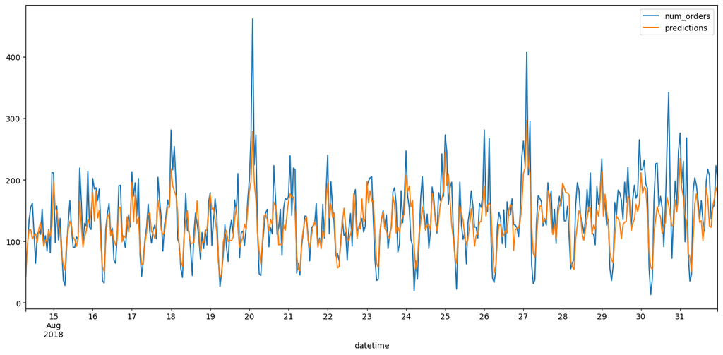

```python
# Наложим график нашего предсказания на данные теста.

t_t = pd.DataFrame(target_test)
t_t['predictions'] = predictions
plt.figure(figsize=(16, 24))
plt.subplot(312)
t_t.plot(ax=plt.gca())
plt.show();
```

## Заключение

Для нужд компании Заказчика на основе исторических данных о заказах такси в аэропорт с целью привлечения водителей в период пиковой нагрузки, была построена модель для предсказания потребного количества такси.

1. Проведено исследование временного ряда на предмет трендовых и сезонных закономерностей, случайной составляющей. Выяснили, что ряд имеет следующие характеристики:

   Есть общий тренд и он растущий; Существует не дельная и суточная сезонность; Присутствует случайная составляющая.
2. Сформированы следующие признаки для обучения модели:
   - номера наблюдения,
   - квадрат номера наблюдения, для учёта нелинейности тренда;
   - номер дня в месяце, для учёта внутримесячных сезонностей;
   - номер дня в неделе, для учёта внутринедельных сезонностей;
   - номер часа в сутках, для учёта внутридневных сезонностей;
   - лаги в диапазоне от 1 и 24 часов, для учёта внутридневной сезонности;
   - лаг в 7 * 24 часа, для учёта недельной сезонности;
   - скользящие средние с окном 12 часов.
1. Наилучшие результаты показала модель `LinearRegression`

[output not shown]

1. Данная модель удовлетворяет требование ТЗ по значению метрики RMSE - оно на тестовой выборке должно быть не больше 48.
2. r2_score равен 0,62, что указывает на то, что 62% дисперсии целевого признака (количества заказов такси) можно объяснить с помощью нашей модели.
3. Из сравнения графиков видно, что предсказаное значение адекватно тестовым значениям, хотя отстаёт в экстремумах.